# Learning Data Science with R

CS2501

2025-08-10

# Learning Data Science with R

Welcome to the **ultimate guide** to learning **Data Science** with **R**. This guide is designed to help you master data science concepts while learning R, one of the most popular programming languages for data analysis and visualization.

## Table of Contents

1. Introduction
2. What is Data Science?
3. Why Learn R?
4. Key Topics
   - Programming with R
   - Data Visualization in R
   - Statistics and Probability
   - Statistical Models and Machine Learning
5. Our Progress
6. Resources
7. Conclusion

| ## Introduction |
| --- |
| Data Science is a multidisciplinary field that combines **mathematics**, **statistics**, **computer science**, and **domain knowledge** to extract insights from data. |
| > *“R is not just a statistical language; it’s a complete ecosystem for data science.”* |

## What is Data Science?

Data science involves five key steps:

1. **Data Collection**
2. **Data Cleaning**
3. **Exploratory Data Analysis (EDA)**
4. **Model Building**
5. **Data Visualization and Communication**

## Why Learn R?

R is a **powerful language** for statistical analysis, data visualization, and machine learning. Some benefits include:

- Excellent libraries for data science (e.g., `dplyr`, `ggplot2`).
- Strong community support.
- Built-in tools for statistical modeling.
- Seamless integration with visualization libraries.

[figure not shown]

**R packages for data science**

Here is an example of creating a bar chart in R:

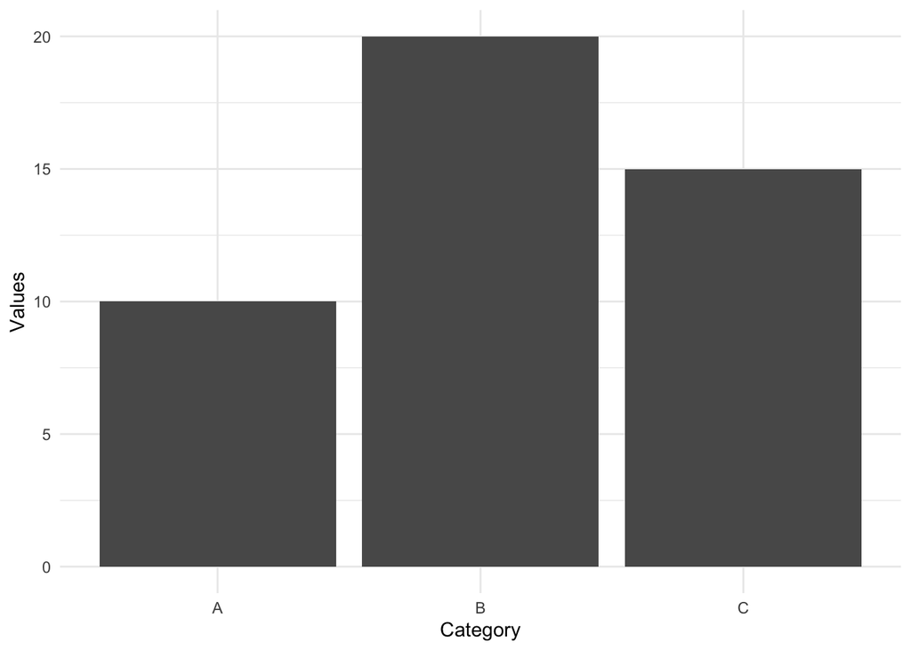

```r
# Load the ggplot2 library
library(ggplot2)

# Create a simple dataset
data <- data.frame(
  Category = c("A", "B", "C"),
  Values = c(10, 20, 15)
)

# Plot a bar chart
data |> ggplot(aes(x = Category, y = Values)) +
  geom_bar(stat = "identity") +
  theme_minimal()
```

## Key Topics

### Programming with R

R is the primary language for this course. Key concepts include:

- **Data Structures**: Vectors, matrices, lists, and data frames.
- **Data Manipulation**: Using `tidyverse` to filter, group, and summarize data.
- **Writing Functions**: Creating reusable code.

#### Example Table of Data Structures in R

| **Structure** | **Description** | **Example** |
| --- | --- | --- |
| **Vector** | A sequence of data elements of the same basic type. | `c(1, 2, 3)` |
| **Matrix** | A 2D array where all elements are of the same type. | `matrix(1:6, nrow = 2, ncol = 3)` |
| **List** | A collection of elements that can be of different types. | `list(a = 1, b = "text", c = TRUE)` |
| **Data Frame** | A table or two-dimensional array-like structure. | `data.frame(x = 1:3, y = c("a", "b", "c"))` |

[output not shown]

Example:

```r
# Create a vector
numbers <- c(1, 2, 3, 4, 5)

# Calculate the mean
mean(numbers)
```

```
## [1] 3
```

### Statistics and Probability

R is excellent for statistical analysis. Topics include:

- Probability Theories
- Probability Distributions and Statistical Inference
- Hypothesis Testing
- Bayesian Statistics
- Regression Analysis

Example:

```r
# Perform linear regression
data(mtcars)
model <- lm(mpg ~ wt, data = mtcars)

# Display a summary of the regression model
summary(model)
```

```
##
## Call:
## lm(formula = mpg ~ wt, data = mtcars)
##
## Residuals:
##     Min      1Q  Median      3Q     Max
## -4.5432 -2.3647 -0.1252  1.4096  6.8727
##
## Coefficients:
##             Estimate Std. Error t value Pr(>|t|)
## (Intercept)  37.2851     1.8776  19.858  < 2e-16 ***
## wt           -5.3445     0.5591  -9.559 1.29e-10 ***
## ---
## Signif. codes:  0 '***' 0.001 '**' 0.01 '*' 0.05 '.' 0.1 ' ' 1
##
## Residual standard error: 3.046 on 30 degrees of freedom
## Multiple R-squared:  0.7528, Adjusted R-squared:  0.7446
## F-statistic: 91.38 on 1 and 30 DF,  p-value: 1.294e-10
```

### Data Visualization in R

Visualization is a critical skill in data science. R offers powerful libraries like:

- **ggplot2**: For creating beautiful graphics.
- **plotly**: For interactive visualizations.

Here’s an example of a scatter plot:

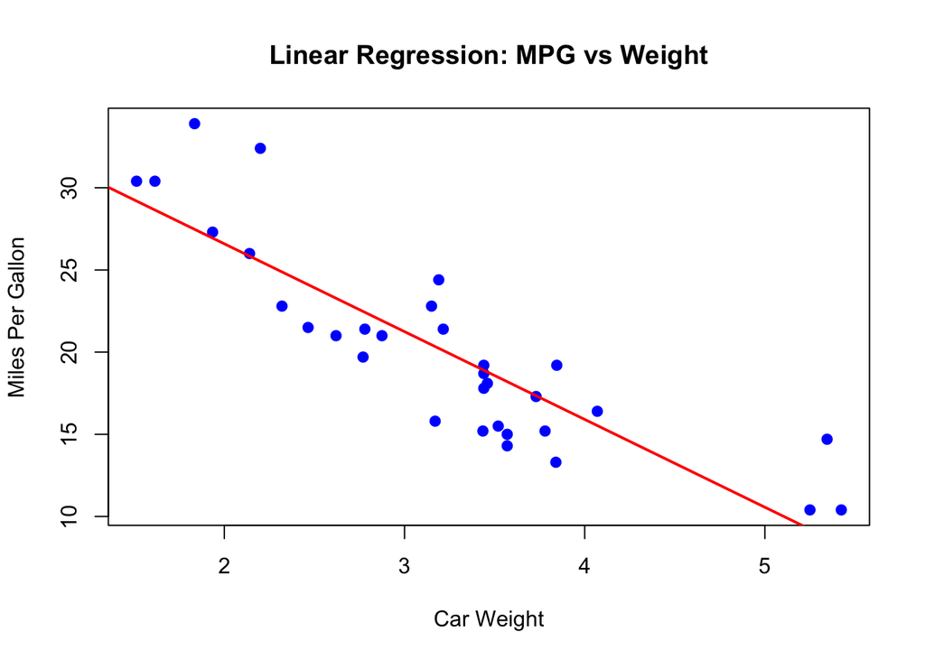

```r
# Scatter plot with ggplot2
plot(mtcars$wt, mtcars$mpg,
     main = "Linear Regression: MPG vs Weight",
     xlab = "Car Weight",
     ylab = "Miles Per Gallon",
     pch = 19, col = "blue")

# Add the regression line
abline(model, col = "red", lwd = 2)
```

### Statistical Models and Machine Learning

R has a variety of machine learning packages, such as:

- **caret**
- **randomForest**
- **xgboost**

Steps in building a machine learning model:

1. Split the dataset into training and testing sets.
2. Train a model using algorithms like linear regression or decision trees.
3. Evaluate the model’s performance using metrics like accuracy or RMSE.

Example:

```r
# Split data into training and testing sets
library(caret)
set.seed(123)
split <- createDataPartition(mtcars$mpg, p = 0.8, list = FALSE)
train <- mtcars[split, ]
test <- mtcars[-split, ]

# Train a linear regression model
model <- train(mpg ~ ., data = train, method = "lm")

# Summarize the model
summary(model)
```

```
##
## Call:
## lm(formula = .outcome ~ ., data = dat)
##
## Residuals:
##     Min      1Q  Median      3Q     Max
## -3.2742 -1.3609 -0.2707  1.1921  4.9877
##
## Coefficients:
##             Estimate Std. Error t value Pr(>|t|)
## (Intercept) -2.81069   22.93545  -0.123    0.904
## cyl          0.75593    1.21576   0.622    0.542
## disp         0.01172    0.01674   0.700    0.494
## hp          -0.01386    0.02197  -0.631    0.536
## drat         2.24007    1.77251   1.264    0.223
## wt          -2.73273    1.87954  -1.454    0.164
## qsec         0.53957    0.71812   0.751    0.463
## vs           1.21640    2.02623   0.600    0.556
## am           1.73662    2.08358   0.833    0.416
## gear         2.95127    1.88459   1.566    0.136
## carb        -1.19910    0.98232  -1.221    0.239
##
## Residual standard error: 2.431 on 17 degrees of freedom
## Multiple R-squared:  0.8861, Adjusted R-squared:  0.8191
## F-statistic: 13.23 on 10 and 17 DF,  p-value: 3.719e-06
```

## Our Progress

- Set up R and RStudio
- Learn basic R syntax
- Learn data manipulation with `dplyr`
- Explore data visualization with `ggplot2`
- Build your data science project

## Resources

Here are some recommended resources to learn R and data science:

1. **Books**
   - *Introduction to Data Science* by Rafael A. Irizarry
   - *R for Data Science* by Hadley Wickham and Garrett Grolemund.
2. **Cheat Sheets**
   - [RStudio Cheat Sheets](https://www.rstudio.com/resources/cheatsheets/)
3. **Communities**
   - [RStudio Community](https://community.rstudio.com)
   - [Stack Overflow](https://stackoverflow.com)

## Conclusion

R is an indispensable tool for data scientists. By mastering it, you’ll gain the ability to analyze, visualize, and model data effectively.